# Risk Factor Analysis

## Outcome Variable

**Outcome Variable:** pers_wast

## Predictor Variables

**Intervention Variable:** impfloor

**Adjustment Set:**

unadjusted

## Stratifying Variables

The analysis was stratified on these variable(s):

- agecat
- studyid
- country

## Data Summary

| agecat | studyid | country | impfloor | pers_wast | n_cell | n | outcome_variable |
| --- | --- | --- | --- | --- | --- | --- | --- |
| 0-24 months | ki0047075b-MAL-ED | BANGLADESH | 1 | 0 | 212 | 242 | pers_wast |
| 0-24 months | ki0047075b-MAL-ED | BANGLADESH | 1 | 1 | 11 | 242 | pers_wast |
| 0-24 months | ki0047075b-MAL-ED | BANGLADESH | 0 | 0 | 17 | 242 | pers_wast |
| 0-24 months | ki0047075b-MAL-ED | BANGLADESH | 0 | 1 | 2 | 242 | pers_wast |
| 0-24 months | ki0047075b-MAL-ED | BRAZIL | 1 | 0 | 206 | 210 | pers_wast |
| 0-24 months | ki0047075b-MAL-ED | BRAZIL | 1 | 1 | 2 | 210 | pers_wast |
| 0-24 months | ki0047075b-MAL-ED | BRAZIL | 0 | 0 | 2 | 210 | pers_wast |
| 0-24 months | ki0047075b-MAL-ED | BRAZIL | 0 | 1 | 0 | 210 | pers_wast |
| 0-24 months | ki0047075b-MAL-ED | INDIA | 1 | 0 | 201 | 235 | pers_wast |
| 0-24 months | ki0047075b-MAL-ED | INDIA | 1 | 1 | 19 | 235 | pers_wast |
| 0-24 months | ki0047075b-MAL-ED | INDIA | 0 | 0 | 14 | 235 | pers_wast |
| 0-24 months | ki0047075b-MAL-ED | INDIA | 0 | 1 | 1 | 235 | pers_wast |
| 0-24 months | ki0047075b-MAL-ED | NEPAL | 1 | 0 | 102 | 229 | pers_wast |
| 0-24 months | ki0047075b-MAL-ED | NEPAL | 1 | 1 | 1 | 229 | pers_wast |
| 0-24 months | ki0047075b-MAL-ED | NEPAL | 0 | 0 | 124 | 229 | pers_wast |
| 0-24 months | ki0047075b-MAL-ED | NEPAL | 0 | 1 | 2 | 229 | pers_wast |
| 0-24 months | ki0047075b-MAL-ED | PERU | 1 | 0 | 58 | 271 | pers_wast |
| 0-24 months | ki0047075b-MAL-ED | PERU | 1 | 1 | 0 | 271 | pers_wast |
| 0-24 months | ki0047075b-MAL-ED | PERU | 0 | 0 | 212 | 271 | pers_wast |
| 0-24 months | ki0047075b-MAL-ED | PERU | 0 | 1 | 1 | 271 | pers_wast |
| 0-24 months | ki0047075b-MAL-ED | SOUTH AFRICA | 1 | 0 | 233 | 256 | pers_wast |
| 0-24 months | ki0047075b-MAL-ED | SOUTH AFRICA | 1 | 1 | 2 | 256 | pers_wast |
| 0-24 months | ki0047075b-MAL-ED | SOUTH AFRICA | 0 | 0 | 21 | 256 | pers_wast |
| 0-24 months | ki0047075b-MAL-ED | SOUTH AFRICA | 0 | 1 | 0 | 256 | pers_wast |
| 0-24 months | ki0047075b-MAL-ED | TANZANIA, UNITED REPUBLIC OF | 1 | 0 | 14 | 248 | pers_wast |
| 0-24 months | ki0047075b-MAL-ED | TANZANIA, UNITED REPUBLIC OF | 1 | 1 | 0 | 248 | pers_wast |
| 0-24 months | ki0047075b-MAL-ED | TANZANIA, UNITED REPUBLIC OF | 0 | 0 | 234 | 248 | pers_wast |
| 0-24 months | ki0047075b-MAL-ED | TANZANIA, UNITED REPUBLIC OF | 0 | 1 | 0 | 248 | pers_wast |
| 0-24 months | ki1000108-CMC-V-BCS-2002 | INDIA | 1 | 0 | 248 | 261 | pers_wast |
| 0-24 months | ki1000108-CMC-V-BCS-2002 | INDIA | 1 | 1 | 13 | 261 | pers_wast |

[output cut: 158 more lines]

The following strata were considered:

- agecat: 0-24 months, studyid: ki0047075b-MAL-ED, country: BANGLADESH
- agecat: 0-24 months, studyid: ki0047075b-MAL-ED, country: BRAZIL
- agecat: 0-24 months, studyid: ki0047075b-MAL-ED, country: INDIA
- agecat: 0-24 months, studyid: ki0047075b-MAL-ED, country: NEPAL
- agecat: 0-24 months, studyid: ki0047075b-MAL-ED, country: PERU
- agecat: 0-24 months, studyid: ki0047075b-MAL-ED, country: SOUTH AFRICA
- agecat: 0-24 months, studyid: ki0047075b-MAL-ED, country: TANZANIA, UNITED REPUBLIC OF
- agecat: 0-24 months, studyid: ki1000108-CMC-V-BCS-2002, country: INDIA
- agecat: 0-24 months, studyid: ki1000108-IRC, country: INDIA
- agecat: 0-24 months, studyid: ki1017093-NIH-Birth, country: BANGLADESH
- agecat: 0-24 months, studyid: ki1017093b-PROVIDE, country: BANGLADESH
- agecat: 0-24 months, studyid: ki1017093c-NIH-Crypto, country: BANGLADESH
- agecat: 0-24 months, studyid: ki1113344-GMS-Nepal, country: NEPAL
- agecat: 0-24 months, studyid: ki1114097-CONTENT, country: PERU
- agecat: 0-24 months, studyid: kiGH5241-JiVitA-3, country: BANGLADESH
- agecat: 0-24 months, studyid: kiGH5241-JiVitA-4, country: BANGLADESH
- agecat: 0-6 months, studyid: ki0047075b-MAL-ED, country: BANGLADESH
- agecat: 0-6 months, studyid: ki0047075b-MAL-ED, country: BRAZIL
- agecat: 0-6 months, studyid: ki0047075b-MAL-ED, country: INDIA
- agecat: 0-6 months, studyid: ki0047075b-MAL-ED, country: NEPAL
- agecat: 0-6 months, studyid: ki0047075b-MAL-ED, country: PERU
- agecat: 0-6 months, studyid: ki0047075b-MAL-ED, country: SOUTH AFRICA
- agecat: 0-6 months, studyid: ki0047075b-MAL-ED, country: TANZANIA, UNITED REPUBLIC OF
- agecat: 0-6 months, studyid: ki1000108-CMC-V-BCS-2002, country: INDIA
- agecat: 0-6 months, studyid: ki1000108-IRC, country: INDIA
- agecat: 0-6 months, studyid: ki1017093-NIH-Birth, country: BANGLADESH
- agecat: 0-6 months, studyid: ki1017093b-PROVIDE, country: BANGLADESH
- agecat: 0-6 months, studyid: ki1017093c-NIH-Crypto, country: BANGLADESH
- agecat: 0-6 months, studyid: ki1113344-GMS-Nepal, country: NEPAL
- agecat: 0-6 months, studyid: ki1114097-CONTENT, country: PERU
- agecat: 0-6 months, studyid: kiGH5241-JiVitA-3, country: BANGLADESH
- agecat: 6-24 months, studyid: ki0047075b-MAL-ED, country: BANGLADESH
- agecat: 6-24 months, studyid: ki0047075b-MAL-ED, country: BRAZIL
- agecat: 6-24 months, studyid: ki0047075b-MAL-ED, country: INDIA
- agecat: 6-24 months, studyid: ki0047075b-MAL-ED, country: NEPAL
- agecat: 6-24 months, studyid: ki0047075b-MAL-ED, country: PERU
- agecat: 6-24 months, studyid: ki0047075b-MAL-ED, country: SOUTH AFRICA
- agecat: 6-24 months, studyid: ki0047075b-MAL-ED, country: TANZANIA, UNITED REPUBLIC OF
- agecat: 6-24 months, studyid: ki1000108-CMC-V-BCS-2002, country: INDIA
- agecat: 6-24 months, studyid: ki1000108-IRC, country: INDIA
- agecat: 6-24 months, studyid: ki1017093-NIH-Birth, country: BANGLADESH
- agecat: 6-24 months, studyid: ki1017093b-PROVIDE, country: BANGLADESH
- agecat: 6-24 months, studyid: ki1017093c-NIH-Crypto, country: BANGLADESH
- agecat: 6-24 months, studyid: ki1113344-GMS-Nepal, country: NEPAL
- agecat: 6-24 months, studyid: ki1114097-CONTENT, country: PERU
- agecat: 6-24 months, studyid: kiGH5241-JiVitA-3, country: BANGLADESH
- agecat: 6-24 months, studyid: kiGH5241-JiVitA-4, country: BANGLADESH

### Dropped Strata

Some strata were dropped due to rare outcomes:

- agecat: 0-24 months, studyid: ki0047075b-MAL-ED, country: BANGLADESH
- agecat: 0-24 months, studyid: ki0047075b-MAL-ED, country: BRAZIL
- agecat: 0-24 months, studyid: ki0047075b-MAL-ED, country: INDIA
- agecat: 0-24 months, studyid: ki0047075b-MAL-ED, country: NEPAL
- agecat: 0-24 months, studyid: ki0047075b-MAL-ED, country: PERU
- agecat: 0-24 months, studyid: ki0047075b-MAL-ED, country: SOUTH AFRICA
- agecat: 0-24 months, studyid: ki0047075b-MAL-ED, country: TANZANIA, UNITED REPUBLIC OF
- agecat: 0-24 months, studyid: ki1000108-CMC-V-BCS-2002, country: INDIA
- agecat: 0-24 months, studyid: ki1000108-IRC, country: INDIA
- agecat: 0-24 months, studyid: ki1017093b-PROVIDE, country: BANGLADESH
- agecat: 0-24 months, studyid: ki1114097-CONTENT, country: PERU
- agecat: 0-6 months, studyid: ki0047075b-MAL-ED, country: BANGLADESH
- agecat: 0-6 months, studyid: ki0047075b-MAL-ED, country: BRAZIL
- agecat: 0-6 months, studyid: ki0047075b-MAL-ED, country: INDIA
- agecat: 0-6 months, studyid: ki0047075b-MAL-ED, country: NEPAL
- agecat: 0-6 months, studyid: ki0047075b-MAL-ED, country: PERU
- agecat: 0-6 months, studyid: ki0047075b-MAL-ED, country: SOUTH AFRICA
- agecat: 0-6 months, studyid: ki0047075b-MAL-ED, country: TANZANIA, UNITED REPUBLIC OF
- agecat: 0-6 months, studyid: ki1000108-CMC-V-BCS-2002, country: INDIA
- agecat: 0-6 months, studyid: ki1000108-IRC, country: INDIA
- agecat: 0-6 months, studyid: ki1017093-NIH-Birth, country: BANGLADESH
- agecat: 0-6 months, studyid: ki1017093b-PROVIDE, country: BANGLADESH
- agecat: 0-6 months, studyid: ki1017093c-NIH-Crypto, country: BANGLADESH
- agecat: 0-6 months, studyid: ki1114097-CONTENT, country: PERU
- agecat: 0-6 months, studyid: kiGH5241-JiVitA-3, country: BANGLADESH
- agecat: 6-24 months, studyid: ki0047075b-MAL-ED, country: BANGLADESH
- agecat: 6-24 months, studyid: ki0047075b-MAL-ED, country: BRAZIL
- agecat: 6-24 months, studyid: ki0047075b-MAL-ED, country: INDIA
- agecat: 6-24 months, studyid: ki0047075b-MAL-ED, country: NEPAL
- agecat: 6-24 months, studyid: ki0047075b-MAL-ED, country: PERU
- agecat: 6-24 months, studyid: ki0047075b-MAL-ED, country: SOUTH AFRICA
- agecat: 6-24 months, studyid: ki0047075b-MAL-ED, country: TANZANIA, UNITED REPUBLIC OF
- agecat: 6-24 months, studyid: ki1000108-CMC-V-BCS-2002, country: INDIA
- agecat: 6-24 months, studyid: ki1000108-IRC, country: INDIA
- agecat: 6-24 months, studyid: ki1017093b-PROVIDE, country: BANGLADESH
- agecat: 6-24 months, studyid: ki1114097-CONTENT, country: PERU

## Methods Detail

We’re interested in the causal parameters $E[Y_a]$ for all values of $a \in \mathcal{A}$. These parameters represent the mean outcome if, possibly contrary to fact, we intervened to set all units to have $A=a$. Under the randomization and positivity assumptions, these are identified by the statistical parameters $\psi_a=E_W[E_{Y|A,W}(Y|A=a,W)]$. In addition, we’re interested in the mean of $Y$, $E[Y]$ under no intervention (the observed mean). We will estimate these parameters by using SuperLearner to fit the relevant likelihood factors – $E_{Y|A,W}(Y|A=a,W)$ and $p(A=a|W)$, and then updating our likelihood fit using a joint TMLE.

For unadjusted analyses ($W=\{\}$), initial likelihoods were estimated using Lrnr_glm to estimate the simple $E(Y|A)$ and Lrnr_mean to estimate $p(A)$. For adjusted analyses, a small library containing Lrnr_glmnet, Lrnr_xgboost, and Lrnr_mean was used.

Having estimated these parameters, we will then use the delta method to estimate relative risks and attributable risks relative to a prespecified baseline level of $A$.

# Results Detail

## Results Plots

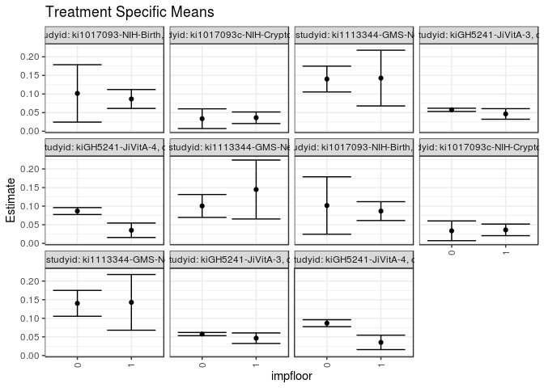

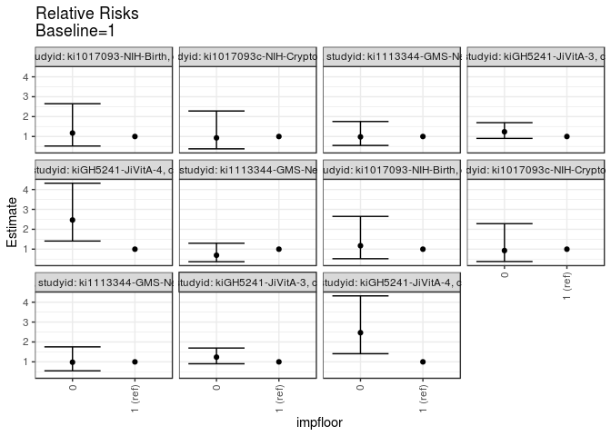

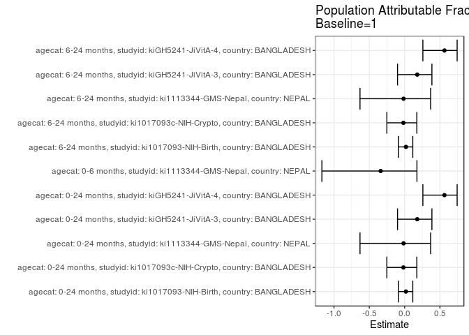

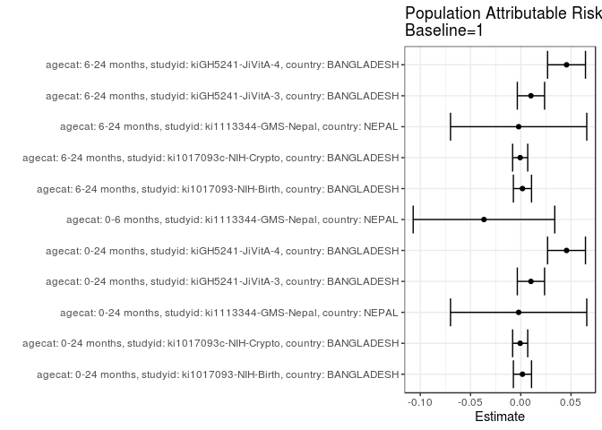

## Results Table

### Parameter: TSM

| agecat | studyid | country | intervention_level | baseline_level | estimate | ci_lower | ci_upper |
| --- | --- | --- | --- | --- | --- | --- | --- |
| 0-24 months | ki1017093-NIH-Birth | BANGLADESH | 1 | NA | 0.0866808 | 0.0613003 | 0.1120612 |
| 0-24 months | ki1017093-NIH-Birth | BANGLADESH | 0 | NA | 0.1016949 | 0.0244994 | 0.1788905 |
| 0-24 months | ki1017093c-NIH-Crypto | BANGLADESH | 1 | NA | 0.0362319 | 0.0206325 | 0.0518313 |
| 0-24 months | ki1017093c-NIH-Crypto | BANGLADESH | 0 | NA | 0.0337079 | 0.0071767 | 0.0602390 |
| 0-24 months | ki1113344-GMS-Nepal | NEPAL | 1 | NA | 0.1428571 | 0.0679455 | 0.2177688 |
| 0-24 months | ki1113344-GMS-Nepal | NEPAL | 0 | NA | 0.1402597 | 0.1055356 | 0.1749839 |
| 0-24 months | kiGH5241-JiVitA-3 | BANGLADESH | 1 | NA | 0.0464779 | 0.0322956 | 0.0606601 |
| 0-24 months | kiGH5241-JiVitA-3 | BANGLADESH | 0 | NA | 0.0575360 | 0.0532260 | 0.0618459 |
| 0-24 months | kiGH5241-JiVitA-4 | BANGLADESH | 1 | NA | 0.0352000 | 0.0157800 | 0.0546200 |
| 0-24 months | kiGH5241-JiVitA-4 | BANGLADESH | 0 | NA | 0.0868257 | 0.0775145 | 0.0961369 |
| 0-6 months | ki1113344-GMS-Nepal | NEPAL | 1 | NA | 0.1447368 | 0.0655468 | 0.2239268 |
| 0-6 months | ki1113344-GMS-Nepal | NEPAL | 0 | NA | 0.1005435 | 0.0697839 | 0.1313031 |
| 6-24 months | ki1017093-NIH-Birth | BANGLADESH | 1 | NA | 0.0866808 | 0.0613003 | 0.1120612 |
| 6-24 months | ki1017093-NIH-Birth | BANGLADESH | 0 | NA | 0.1016949 | 0.0244994 | 0.1788905 |
| 6-24 months | ki1017093c-NIH-Crypto | BANGLADESH | 1 | NA | 0.0362319 | 0.0206325 | 0.0518313 |
| 6-24 months | ki1017093c-NIH-Crypto | BANGLADESH | 0 | NA | 0.0337079 | 0.0071767 | 0.0602390 |
| 6-24 months | ki1113344-GMS-Nepal | NEPAL | 1 | NA | 0.1428571 | 0.0679455 | 0.2177688 |
| 6-24 months | ki1113344-GMS-Nepal | NEPAL | 0 | NA | 0.1402597 | 0.1055356 | 0.1749839 |
| 6-24 months | kiGH5241-JiVitA-3 | BANGLADESH | 1 | NA | 0.0464779 | 0.0322956 | 0.0606601 |
| 6-24 months | kiGH5241-JiVitA-3 | BANGLADESH | 0 | NA | 0.0575360 | 0.0532260 | 0.0618459 |
| 6-24 months | kiGH5241-JiVitA-4 | BANGLADESH | 1 | NA | 0.0352000 | 0.0157800 | 0.0546200 |
| 6-24 months | kiGH5241-JiVitA-4 | BANGLADESH | 0 | NA | 0.0868257 | 0.0775145 | 0.0961369 |

### Parameter: E(Y)

| agecat | studyid | country | intervention_level | baseline_level | estimate | ci_lower | ci_upper |
| --- | --- | --- | --- | --- | --- | --- | --- |
| 0-24 months | ki1017093-NIH-Birth | BANGLADESH | NA | NA | 0.0883459 | 0.0642074 | 0.1124843 |
| 0-24 months | ki1017093c-NIH-Crypto | BANGLADESH | NA | NA | 0.0356164 | 0.0221630 | 0.0490699 |
| 0-24 months | ki1113344-GMS-Nepal | NEPAL | NA | NA | 0.1407249 | 0.1092201 | 0.1722298 |
| 0-24 months | kiGH5241-JiVitA-3 | BANGLADESH | NA | NA | 0.0565703 | 0.0524546 | 0.0606859 |
| 0-24 months | kiGH5241-JiVitA-4 | BANGLADESH | NA | NA | 0.0807124 | 0.0720896 | 0.0893352 |
| 0-6 months | ki1113344-GMS-Nepal | NEPAL | NA | NA | 0.1081081 | 0.0791926 | 0.1370237 |
| 6-24 months | ki1017093-NIH-Birth | BANGLADESH | NA | NA | 0.0883459 | 0.0642074 | 0.1124843 |
| 6-24 months | ki1017093c-NIH-Crypto | BANGLADESH | NA | NA | 0.0356164 | 0.0221630 | 0.0490699 |
| 6-24 months | ki1113344-GMS-Nepal | NEPAL | NA | NA | 0.1407249 | 0.1092201 | 0.1722298 |
| 6-24 months | kiGH5241-JiVitA-3 | BANGLADESH | NA | NA | 0.0565703 | 0.0524546 | 0.0606859 |
| 6-24 months | kiGH5241-JiVitA-4 | BANGLADESH | NA | NA | 0.0807124 | 0.0720896 | 0.0893352 |

### Parameter: RR

| agecat | studyid | country | intervention_level | baseline_level | estimate | ci_lower | ci_upper |
| --- | --- | --- | --- | --- | --- | --- | --- |
| 0-24 months | ki1017093-NIH-Birth | BANGLADESH | 1 | 1 | 1.0000000 | 1.0000000 | 1.000000 |
| 0-24 months | ki1017093-NIH-Birth | BANGLADESH | 0 | 1 | 1.1732121 | 0.5200356 | 2.646793 |
| 0-24 months | ki1017093c-NIH-Crypto | BANGLADESH | 1 | 1 | 1.0000000 | 1.0000000 | 1.000000 |
| 0-24 months | ki1017093c-NIH-Crypto | BANGLADESH | 0 | 1 | 0.9303371 | 0.3793263 | 2.281748 |
| 0-24 months | ki1113344-GMS-Nepal | NEPAL | 1 | 1 | 1.0000000 | 1.0000000 | 1.000000 |
| 0-24 months | ki1113344-GMS-Nepal | NEPAL | 0 | 1 | 0.9818182 | 0.5497813 | 1.753364 |
| 0-24 months | kiGH5241-JiVitA-3 | BANGLADESH | 1 | 1 | 1.0000000 | 1.0000000 | 1.000000 |
| 0-24 months | kiGH5241-JiVitA-3 | BANGLADESH | 0 | 1 | 1.2379221 | 0.9040457 | 1.695104 |
| 0-24 months | kiGH5241-JiVitA-4 | BANGLADESH | 1 | 1 | 1.0000000 | 1.0000000 | 1.000000 |
| 0-24 months | kiGH5241-JiVitA-4 | BANGLADESH | 0 | 1 | 2.4666393 | 1.4094445 | 4.316814 |
| 0-6 months | ki1113344-GMS-Nepal | NEPAL | 1 | 1 | 1.0000000 | 1.0000000 | 1.000000 |
| 0-6 months | ki1113344-GMS-Nepal | NEPAL | 0 | 1 | 0.6946640 | 0.3711377 | 1.300213 |
| 6-24 months | ki1017093-NIH-Birth | BANGLADESH | 1 | 1 | 1.0000000 | 1.0000000 | 1.000000 |
| 6-24 months | ki1017093-NIH-Birth | BANGLADESH | 0 | 1 | 1.1732121 | 0.5200356 | 2.646793 |
| 6-24 months | ki1017093c-NIH-Crypto | BANGLADESH | 1 | 1 | 1.0000000 | 1.0000000 | 1.000000 |
| 6-24 months | ki1017093c-NIH-Crypto | BANGLADESH | 0 | 1 | 0.9303371 | 0.3793263 | 2.281748 |
| 6-24 months | ki1113344-GMS-Nepal | NEPAL | 1 | 1 | 1.0000000 | 1.0000000 | 1.000000 |
| 6-24 months | ki1113344-GMS-Nepal | NEPAL | 0 | 1 | 0.9818182 | 0.5497813 | 1.753364 |
| 6-24 months | kiGH5241-JiVitA-3 | BANGLADESH | 1 | 1 | 1.0000000 | 1.0000000 | 1.000000 |
| 6-24 months | kiGH5241-JiVitA-3 | BANGLADESH | 0 | 1 | 1.2379221 | 0.9040457 | 1.695104 |
| 6-24 months | kiGH5241-JiVitA-4 | BANGLADESH | 1 | 1 | 1.0000000 | 1.0000000 | 1.000000 |
| 6-24 months | kiGH5241-JiVitA-4 | BANGLADESH | 0 | 1 | 2.4666393 | 1.4094445 | 4.316814 |

### Parameter: PAR

| agecat | studyid | country | intervention_level | baseline_level | estimate | ci_lower | ci_upper |
| --- | --- | --- | --- | --- | --- | --- | --- |
| 0-24 months | ki1017093-NIH-Birth | BANGLADESH | 1 | NA | 0.0016651 | -0.0073558 | 0.0106860 |
| 0-24 months | ki1017093c-NIH-Crypto | BANGLADESH | 1 | NA | -0.0006154 | -0.0081205 | 0.0068896 |
| 0-24 months | ki1113344-GMS-Nepal | NEPAL | 1 | NA | -0.0021322 | -0.0699122 | 0.0656478 |
| 0-24 months | kiGH5241-JiVitA-3 | BANGLADESH | 1 | NA | 0.0100924 | -0.0034531 | 0.0236380 |
| 0-24 months | kiGH5241-JiVitA-4 | BANGLADESH | 1 | NA | 0.0455124 | 0.0266682 | 0.0643565 |
| 0-6 months | ki1113344-GMS-Nepal | NEPAL | 1 | NA | -0.0366287 | -0.1070583 | 0.0338008 |
| 6-24 months | ki1017093-NIH-Birth | BANGLADESH | 1 | NA | 0.0016651 | -0.0073558 | 0.0106860 |
| 6-24 months | ki1017093c-NIH-Crypto | BANGLADESH | 1 | NA | -0.0006154 | -0.0081205 | 0.0068896 |
| 6-24 months | ki1113344-GMS-Nepal | NEPAL | 1 | NA | -0.0021322 | -0.0699122 | 0.0656478 |
| 6-24 months | kiGH5241-JiVitA-3 | BANGLADESH | 1 | NA | 0.0100924 | -0.0034531 | 0.0236380 |
| 6-24 months | kiGH5241-JiVitA-4 | BANGLADESH | 1 | NA | 0.0455124 | 0.0266682 | 0.0643565 |

### Parameter: PAF

| agecat | studyid | country | intervention_level | baseline_level | estimate | ci_lower | ci_upper |
| --- | --- | --- | --- | --- | --- | --- | --- |
| 0-24 months | ki1017093-NIH-Birth | BANGLADESH | 1 | NA | 0.0188476 | -0.0886474 | 0.1157282 |
| 0-24 months | ki1017093c-NIH-Crypto | BANGLADESH | 1 | NA | -0.0172798 | -0.2512945 | 0.1729699 |
| 0-24 months | ki1113344-GMS-Nepal | NEPAL | 1 | NA | -0.0151515 | -0.6314841 | 0.3683465 |
| 0-24 months | kiGH5241-JiVitA-3 | BANGLADESH | 1 | NA | 0.1784050 | -0.1001673 | 0.3864402 |
| 0-24 months | kiGH5241-JiVitA-4 | BANGLADESH | 1 | NA | 0.5638836 | 0.2583934 | 0.7435331 |
| 0-6 months | ki1113344-GMS-Nepal | NEPAL | 1 | NA | -0.3388158 | -1.1710243 | 0.1743862 |
| 6-24 months | ki1017093-NIH-Birth | BANGLADESH | 1 | NA | 0.0188476 | -0.0886474 | 0.1157282 |
| 6-24 months | ki1017093c-NIH-Crypto | BANGLADESH | 1 | NA | -0.0172798 | -0.2512945 | 0.1729699 |
| 6-24 months | ki1113344-GMS-Nepal | NEPAL | 1 | NA | -0.0151515 | -0.6314841 | 0.3683465 |
| 6-24 months | kiGH5241-JiVitA-3 | BANGLADESH | 1 | NA | 0.1784050 | -0.1001673 | 0.3864402 |
| 6-24 months | kiGH5241-JiVitA-4 | BANGLADESH | 1 | NA | 0.5638836 | 0.2583934 | 0.7435331 |